## title: “Predict_Income_Income_Level”

author: “steve dubois” date: “3/21/2019” output: html_document: default pdf_document: default —

## ABSTRACT

The prominent inequality of wealth and income is a huge concern especially in the United States. The likelihood of diminishing poverty is one valid reason to reduce the world’s surging level of economic inequality. The principle of universal moral equality ensures sustainable development and improve the economic stability of a nation. Governments in different countries have been trying their best to address this problem and provide an optimal solution. This study aims to show the usage of machine learning and data mining techniques in providing a solution to the income equality problem. The UCI Adult Dataset has been used for the purpose. Machine learning classification has been done to predict whether a person’s yearly income in US falls in the income category of either greater than 50K Dollars or less equal to 50K Dollars category based on a certain set of attributes.

```r
  library(ISLR)
  library(gmodels)
  library(broom)
  library(tidyverse)
  library(tidyr)
  library(dplyr)
  library(readr)
  library(ggplot2)
  library(randomForest)
  library(caret)
  library(xgboost)
  library(mlr)
  library(optparse)
  library(data.table)
  library(ggplot2)
  library(gbm)
  library(ggpubr)
  library(rpart)
  library(e1071)
  library(rpart.plot)
  library(plotly)
  library(rattle)
  library(GGally)
  library(neuralnet)
  library(nnet)
  library(network)
  library(networkD3)
```

# Loading the Census Data

```r
option_list <- list(
  make_option("--train", type = "character",
              default = "http://archive.ics.uci.edu/ml/machine-learning-databases/adult/adult.data"),
  make_option("--test", type = "character",
              default = "http://archive.ics.uci.edu/ml/machine-learning-databases/adult/adult.test"))

opt <- parse_args(OptionParser(option_list = option_list))
link_train <- opt$train
link_test <- opt$test



#Read the files using the links from args
train <-  read_csv(file = link_train, skip = 1, col_names = TRUE)
test <-  read_csv(file = link_test, skip = 1, col_names = TRUE)
#read the files using the links from args
train <-  read_csv(file = link_train, skip = 1)
test <-  read_csv(file = link_test, skip = 1)
```

```r
#Initializing headers
headings <- c("Age","Work_Class", "Final_Weight", "Education", "Education_Num", "Marital_Status", "Occupation",   "Relationship", "Race", "Sex", "Capital_Gain", "Capital_Loss", "Hours_Per_Week", "Native_Country", "IncomeCLASS")

#Adding headers
names(train) <- headings
names(test) <- headings
train <- as.data.frame(train)
test <- as.data.frame(test)
train$IncomeCLASS <- as.factor(train$IncomeCLASS)
test$IncomeCLASS <- as.factor(test$IncomeCLASS)
levels(train$IncomeCLASS) <- c("Less_50K", "More_50K")
levels(test$IncomeCLASS) <- c("Less_50K", "More_50K")
```

```r
impute.mean <- function(x) replace(x, is.na(x) | is.nan(x) | is.infinite(x), mean(x[!is.na(x) & !is.nan(x) & !is.infinite(x)]))
losses <- apply(train, 2, impute.mean)
sum(apply( losses, 2, function(.) sum(is.infinite(.)) ))
```

```
## [1] 0
```

```r
impute.mean <- function(x) replace(x, is.na(x) | is.nan(x) | is.infinite(x), mean(x[!is.na(x) & !is.nan(x) & !is.infinite(x)]))
losses <- apply(test, 2, impute.mean)
sum(apply( losses, 2, function(.) sum(is.infinite(.)) ))
```

```
## [1] 0
```

# Exploratory Data Analysis Using GGplot

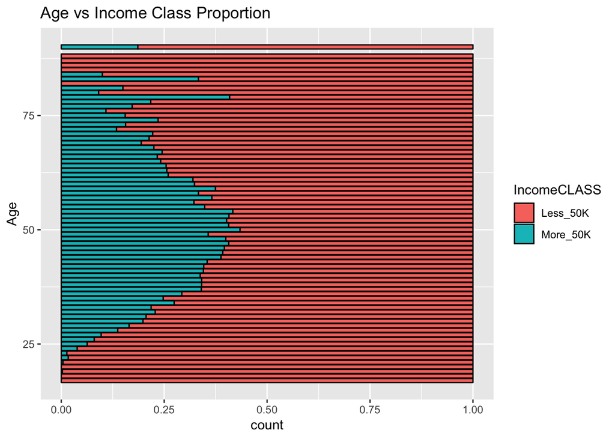

```r
P <- ggplot(train,aes(x = Age, fill = IncomeCLASS)) + geom_bar(position = "fill", color = "black") + coord_flip()

P + labs(title = "Age vs Income Class Proportion")
```

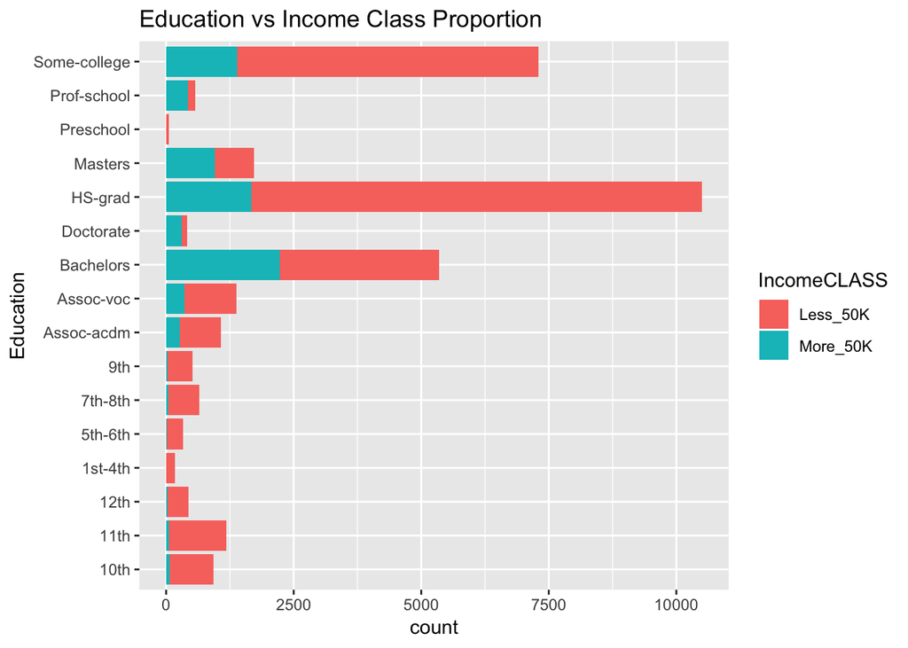

```r
Q <- ggplot(train,aes(x = Education, fill = IncomeCLASS)) + geom_bar() + coord_flip()
Q + labs(title = "Education vs Income Class Proportion")
```

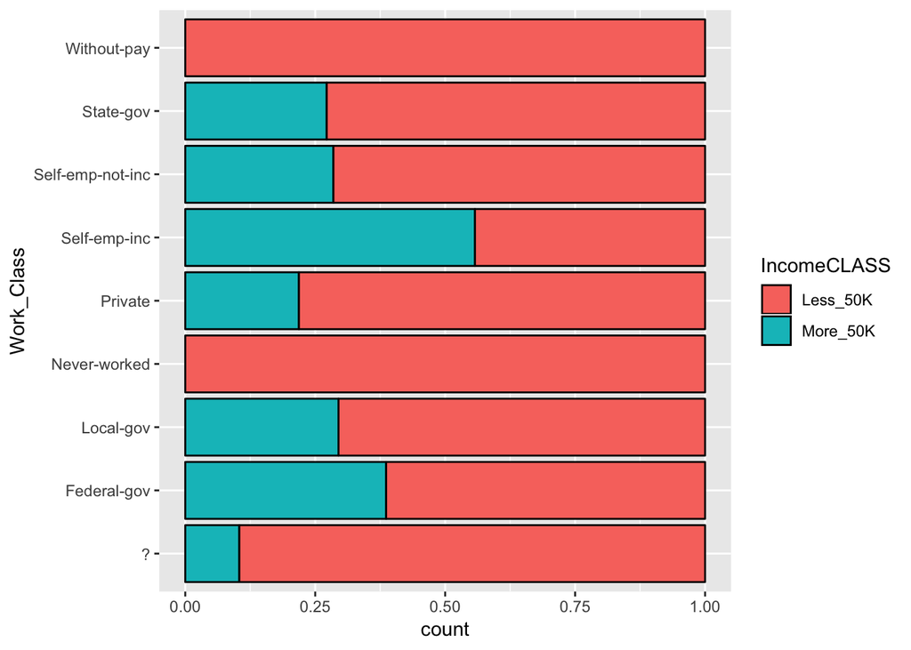

```r
 ggplot(train,aes(x = Work_Class, fill = IncomeCLASS)) + geom_bar(position = "fill", color = "black") + coord_flip()
```

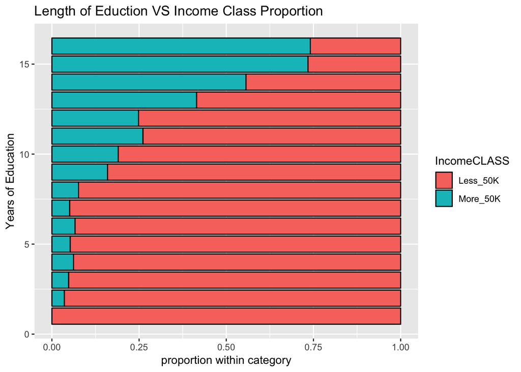

```r
 ggplot(train,aes(x = Education_Num, fill = IncomeCLASS)) + ggtitle("Length of Eduction VS Income Class Proportion") + xlab("Years of Education") + ylab("proportion within category") + geom_bar(position = "fill", color = "black") + coord_flip()
```

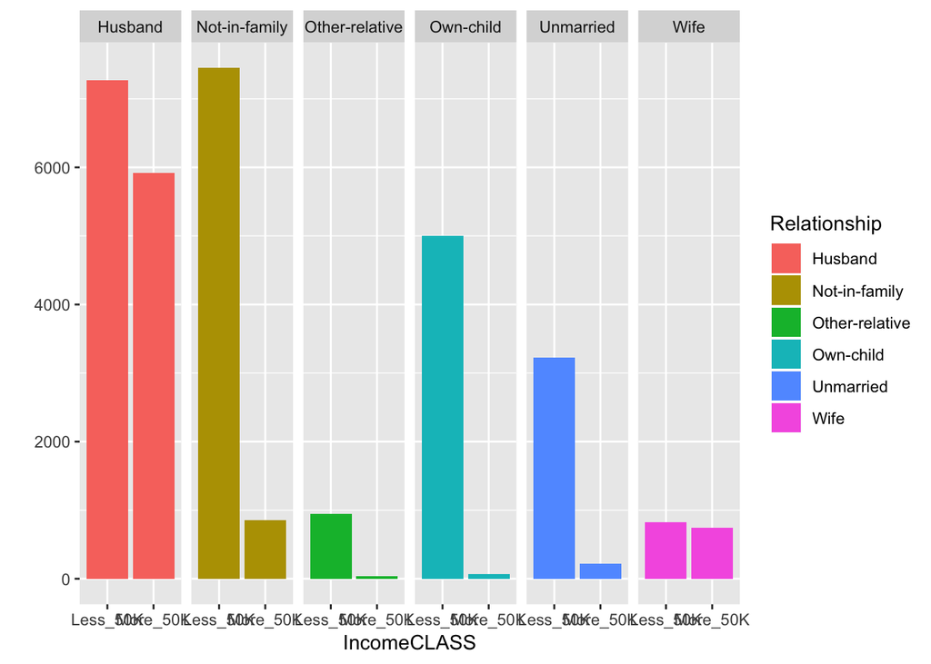

```r
 qplot (IncomeCLASS, data = train, fill = Relationship) + facet_grid (. ~ Relationship)
```

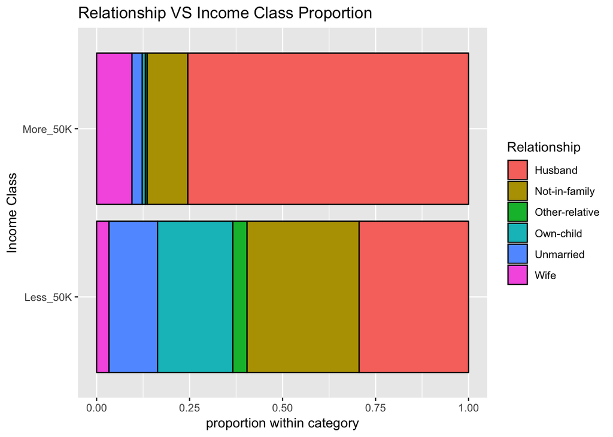

```r
 ggplot(train,aes(x = IncomeCLASS, fill = Relationship)) + ggtitle("Relationship VS Income Class Proportion") + xlab("Income Class") + ylab("proportion within category") + geom_bar(position = "fill", color = "black") + coord_flip()
```

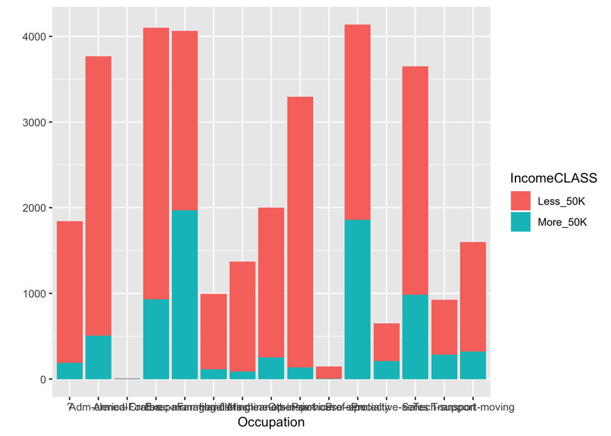

```r
 qplot (Occupation, data = train, fill = IncomeCLASS)
```

[figure not shown]

```r
ggplot(train,aes(x = Occupation, fill = IncomeCLASS)) + ggtitle("Length of Eduction VS Income Class Proportion") + xlab("Years of Education") + ylab("proportion within category") + geom_bar(position = "fill", color = "black") + coord_flip()
```

## LOGISTIC REGRESSION MODEL

```r
# Logistic Regression Model
set.seed (32323)
trCtrl = trainControl (method = "cv", number = 10)
model_logit <- caret::train(IncomeCLASS ~., data = train, method = "glm", tuneGrid=expand.grid(parameter=c(0.001, 0.01, 0.1, 1,10,100, 1000)))
pred_logit <- predict(model_logit, test)
confusionMatrix(pred_logit, test$IncomeCLASS)
```

```
## Confusion Matrix and Statistics
##
##           Reference
## Prediction Less_50K More_50K
##   Less_50K    11577     1543
##   More_50K      857     2303
##
##                Accuracy : 0.8526
##                  95% CI : (0.847, 0.858)
##     No Information Rate : 0.7638
##     P-Value [Acc > NIR] : < 2.2e-16
##
##                   Kappa : 0.5647
##  Mcnemar's Test P-Value : < 2.2e-16
##
##             Sensitivity : 0.9311
##             Specificity : 0.5988
##          Pos Pred Value : 0.8824
##          Neg Pred Value : 0.7288
##              Prevalence : 0.7638
##          Detection Rate : 0.7111
##    Detection Prevalence : 0.8059
##       Balanced Accuracy : 0.7649
##
##        'Positive' Class : Less_50K
##
```

```r
CrossTable(pred_logit, test$IncomeCLASS)
```

```
##
##
##    Cell Contents
## |-------------------------|
## |                       N |
## | Chi-square contribution |
## |           N / Row Total |
## |           N / Col Total |
## |         N / Table Total |
## |-------------------------|
##
##
## Total Observations in Table:  16280
##
##
##              | test$IncomeCLASS
##   pred_logit |  Less_50K |  More_50K | Row Total |
## -------------|-----------|-----------|-----------|
##     Less_50K |     11577 |      1543 |     13120 |
##              |   241.767 |   781.624 |           |
##              |     0.882 |     0.118 |     0.806 |
##              |     0.931 |     0.401 |           |
##              |     0.711 |     0.095 |           |
## -------------|-----------|-----------|-----------|
##     More_50K |       857 |      2303 |      3160 |
##              |  1003.790 |  3245.224 |           |
##              |     0.271 |     0.729 |     0.194 |
##              |     0.069 |     0.599 |           |
##              |     0.053 |     0.141 |           |
## -------------|-----------|-----------|-----------|
## Column Total |     12434 |      3846 |     16280 |
##              |     0.764 |     0.236 |           |
## -------------|-----------|-----------|-----------|
##
##
```

```r
logit_VarImp <- varImp(model_logit, scale = FALSE)
```

## NAIVE BAYES MODEL

```r
#train Naive Bayes
model_Naive <- naiveBayes(IncomeCLASS ~ ., data = train)
pred_Nb <- predict(model_Naive, test)
confusionMatrix(pred_Nb, test$IncomeCLASS)
```

```
## Confusion Matrix and Statistics
##
##           Reference
## Prediction Less_50K More_50K
##   Less_50K    11559     1951
##   More_50K      875     1895
##
##                Accuracy : 0.8264
##                  95% CI : (0.8205, 0.8322)
##     No Information Rate : 0.7638
##     P-Value [Acc > NIR] : < 2.2e-16
##
##                   Kappa : 0.4675
##  Mcnemar's Test P-Value : < 2.2e-16
##
##             Sensitivity : 0.9296
##             Specificity : 0.4927
##          Pos Pred Value : 0.8556
##          Neg Pred Value : 0.6841
##              Prevalence : 0.7638
##          Detection Rate : 0.7100
##    Detection Prevalence : 0.8299
##       Balanced Accuracy : 0.7112
##
##        'Positive' Class : Less_50K
##
```

```r
CrossTable(pred_Nb, test$IncomeCLASS)
```

```
##
##
##    Cell Contents
## |-------------------------|
## |                       N |
## | Chi-square contribution |
## |           N / Row Total |
## |           N / Col Total |
## |         N / Table Total |
## |-------------------------|
##
##
## Total Observations in Table:  16280
##
##
##              | test$IncomeCLASS
##      pred_Nb |  Less_50K |  More_50K | Row Total |
## -------------|-----------|-----------|-----------|
##     Less_50K |     11559 |      1951 |     13510 |
##              |   149.163 |   482.239 |           |
##              |     0.856 |     0.144 |     0.830 |
##              |     0.930 |     0.507 |           |
##              |     0.710 |     0.120 |           |
## -------------|-----------|-----------|-----------|
##     More_50K |       875 |      1895 |      2770 |
##              |   727.506 |  2352.004 |           |
##              |     0.316 |     0.684 |     0.170 |
##              |     0.070 |     0.493 |           |
##              |     0.054 |     0.116 |           |
## -------------|-----------|-----------|-----------|
## Column Total |     12434 |      3846 |     16280 |
##              |     0.764 |     0.236 |           |
## -------------|-----------|-----------|-----------|
##
##
```

```r
summary(pred_Nb)
```

```
## Less_50K More_50K
##    13510     2770
```

## TRAIN THE RPART DECISION TREE MODEL

```r
# rpart decision tree
set.seed(32323)
V <- 10
T <- 4
TrControl <- trainControl(method = "repeatedcv",
                          number = V,
                          repeats = T)


model_part <- caret::train(IncomeCLASS ~., data = train, method = "rpart",  control = rpart::rpart.control(minsplit = 5, cp = 0), tuneGrid = data.frame(cp = .02), trControl = TrControl)
pred_rpart <- predict(model_part, test, type = "raw")

confusionMatrix(pred_rpart, test$IncomeCLASS)
```

```
## Confusion Matrix and Statistics
##
##           Reference
## Prediction Less_50K More_50K
##   Less_50K    11802     1895
##   More_50K      632     1951
##
##                Accuracy : 0.8448
##                  95% CI : (0.8391, 0.8503)
##     No Information Rate : 0.7638
##     P-Value [Acc > NIR] : < 2.2e-16
##
##                   Kappa : 0.5148
##  Mcnemar's Test P-Value : < 2.2e-16
##
##             Sensitivity : 0.9492
##             Specificity : 0.5073
##          Pos Pred Value : 0.8616
##          Neg Pred Value : 0.7553
##              Prevalence : 0.7638
##          Detection Rate : 0.7249
##    Detection Prevalence : 0.8413
##       Balanced Accuracy : 0.7282
##
##        'Positive' Class : Less_50K
##
```

```r
CrossTable(pred_rpart, test$IncomeCLASS)
```

```
##
##
##    Cell Contents
## |-------------------------|
## |                       N |
## | Chi-square contribution |
## |           N / Row Total |
## |           N / Col Total |
## |         N / Table Total |
## |-------------------------|
##
##
## Total Observations in Table:  16280
##
##
##              | test$IncomeCLASS
##   pred_rpart |  Less_50K |  More_50K | Row Total |
## -------------|-----------|-----------|-----------|
##     Less_50K |     11802 |      1895 |     13697 |
##              |   171.846 |   555.573 |           |
##              |     0.862 |     0.138 |     0.841 |
##              |     0.949 |     0.493 |           |
##              |     0.725 |     0.116 |           |
## -------------|-----------|-----------|-----------|
##     More_50K |       632 |      1951 |      2583 |
##              |   911.257 |  2946.065 |           |
##              |     0.245 |     0.755 |     0.159 |
##              |     0.051 |     0.507 |           |
##              |     0.039 |     0.120 |           |
## -------------|-----------|-----------|-----------|
## Column Total |     12434 |      3846 |     16280 |
##              |     0.764 |     0.236 |           |
## -------------|-----------|-----------|-----------|
##
##
```

```r
summary(pred_rpart)
```

```
## Less_50K More_50K
##    13697     2583
```

```r
model_part$finalModel
```

```
## n= 32559
##
## node), split, n, loss, yval, (yprob)
##       * denotes terminal node
##
##  1) root 32559 7841 Less_50K (0.75917565 0.24082435)
##    2) Marital_StatusMarried-civ-spouse< 0.5 17584 1149 Less_50K (0.93465651 0.06534349)
##      4) Capital_Gain< 7073.5 17273  849 Less_50K (0.95084814 0.04915186) *
##      5) Capital_Gain>=7073.5 311   11 More_50K (0.03536977 0.96463023) *
##    3) Marital_StatusMarried-civ-spouse>=0.5 14975 6692 Less_50K (0.55312187 0.44687813)
##      6) Education_Num< 12.5 10507 3478 Less_50K (0.66898258 0.33101742)
##       12) Capital_Gain< 5095.5 9979 2961 Less_50K (0.70327688 0.29672312) *
##       13) Capital_Gain>=5095.5 528   11 More_50K (0.02083333 0.97916667) *
##      7) Education_Num>=12.5 4468 1254 More_50K (0.28066249 0.71933751) *
```

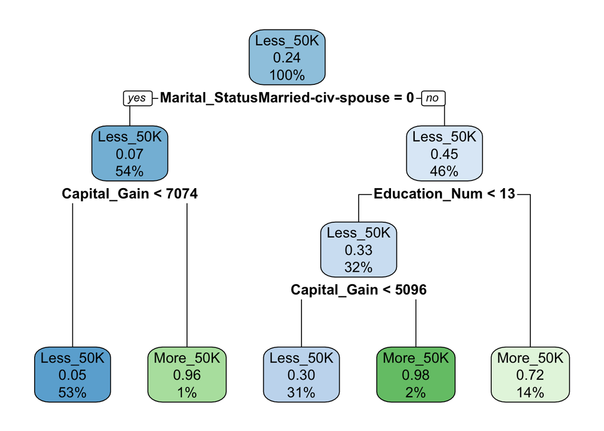

```r
rpart.plot(model_part$finalModel)
```

## TRAIN THE RANDOM FOREST MODEL

```r
levels(test$Native_Country) <- levels(train$Native_Country)
model.rf <- randomForest(IncomeCLASS~., data = train, ntree=500, importance=TRUE)
pred.rf <- predict(model.rf, test)
summary(pred.rf)
```

```
## Less_50K More_50K
##    12134     4146
```

```r
confusionMatrix(test$IncomeCLASS, pred.rf)
```

```
## Confusion Matrix and Statistics
##
##           Reference
## Prediction Less_50K More_50K
##   Less_50K    11048     1386
##   More_50K     1086     2760
##
##                Accuracy : 0.8482
##                  95% CI : (0.8426, 0.8536)
##     No Information Rate : 0.7453
##     P-Value [Acc > NIR] : < 2.2e-16
##
##                   Kappa : 0.5903
##  Mcnemar's Test P-Value : 1.813e-09
##
##             Sensitivity : 0.9105
##             Specificity : 0.6657
##          Pos Pred Value : 0.8885
##          Neg Pred Value : 0.7176
##              Prevalence : 0.7453
##          Detection Rate : 0.6786
##    Detection Prevalence : 0.7638
##       Balanced Accuracy : 0.7881
##
##        'Positive' Class : Less_50K
##
```

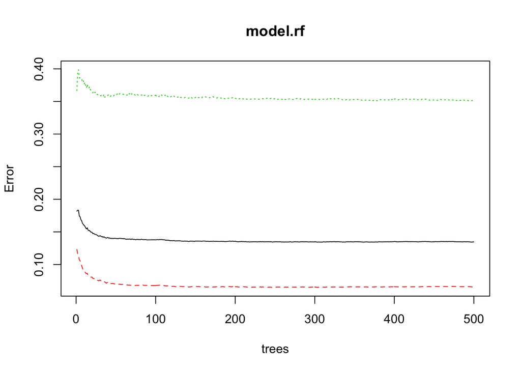

```r
plot(model.rf)
```

## TRAIN THE SVM MODEL

```r
# train the SVM model
set.seed(32323)
library(e1071)
library(rpart)
svm.model <- caret::train(IncomeCLASS~., data = train, method="svmRadial", trControl = trCtrl , verbose = TRUE)
pred.svm <- predict(svm.model, test)
confusionMatrix(pred.svm, test$IncomeCLASS)
```

```
## Confusion Matrix and Statistics
##
##           Reference
## Prediction Less_50K More_50K
##   Less_50K    12405     3760
##   More_50K       29       86
##
##                Accuracy : 0.7673
##                  95% CI : (0.7607, 0.7737)
##     No Information Rate : 0.7638
##     P-Value [Acc > NIR] : 0.1486
##
##                   Kappa : 0.0301
##  Mcnemar's Test P-Value : <2e-16
##
##             Sensitivity : 0.99767
##             Specificity : 0.02236
##          Pos Pred Value : 0.76740
##          Neg Pred Value : 0.74783
##              Prevalence : 0.76376
##          Detection Rate : 0.76198
##    Detection Prevalence : 0.99294
##       Balanced Accuracy : 0.51001
##
##        'Positive' Class : Less_50K
##
```

```r
CrossTable(pred.svm, test$IncomeCLASS)
```

```
##
##
##    Cell Contents
## |-------------------------|
## |                       N |
## | Chi-square contribution |
## |           N / Row Total |
## |           N / Col Total |
## |         N / Table Total |
## |-------------------------|
##
##
## Total Observations in Table:  16280
##
##
##              | test$IncomeCLASS
##     pred.svm |  Less_50K |  More_50K | Row Total |
## -------------|-----------|-----------|-----------|
##     Less_50K |     12405 |      3760 |     16165 |
##              |     0.280 |     0.906 |           |
##              |     0.767 |     0.233 |     0.993 |
##              |     0.998 |     0.978 |           |
##              |     0.762 |     0.231 |           |
## -------------|-----------|-----------|-----------|
##     More_50K |        29 |        86 |       115 |
##              |    39.407 |   127.403 |           |
##              |     0.252 |     0.748 |     0.007 |
##              |     0.002 |     0.022 |           |
##              |     0.002 |     0.005 |           |
## -------------|-----------|-----------|-----------|
## Column Total |     12434 |      3846 |     16280 |
##              |     0.764 |     0.236 |           |
## -------------|-----------|-----------|-----------|
##
##
```

## NEURAL NETWORKS

```r
## NEURAL NETWORKS

# define training control

train_control <- trainControl(method = 'repeatedcv', number = 10, classProbs = TRUE, verboseIter = TRUE, preProcOptions = list(thresh = 0.75, ICAcomp = 3, k = 5))

# train the model

metric <- "Accuracy"

model_neural <- caret::train(IncomeCLASS ~ ., data = train, method = "nnet", MaxNWts = 100000,  metric=metric, preProcess = c('center', 'scale'), trControl = train_control, linout=FALSE)
# summarize results
print(model_neural)
```

```
## Neural Network
##
## 32559 samples
##    14 predictor
##     2 classes: 'Less_50K', 'More_50K'
##
## Pre-processing: centered (100), scaled (100)
## Resampling: Cross-Validated (10 fold, repeated 1 times)
## Summary of sample sizes: 29303, 29304, 29303, 29303, 29303, 29303, ...
## Resampling results across tuning parameters:
##
##   size  decay  Accuracy   Kappa
##   1     0e+00  0.8291101  0.5433206
##   1     1e-04  0.8154120  0.4381158
##   1     1e-01  0.8284353  0.5117565
##   3     0e+00  0.8471698  0.5564951
##   3     1e-04  0.8487974  0.5577484
##   3     1e-01  0.8471693  0.5557684
##   5     0e+00  0.8472924  0.5643642
##   5     1e-04  0.8478757  0.5648720
##   5     1e-01  0.8503946  0.5750513
##
## Accuracy was used to select the optimal model using the largest value.
## The final values used for the model were size = 5 and decay = 0.1.
```

```r
# Confusion matrix
pred_neural <- predict(model_neural, test, type = "raw")
confusionMatrix(pred_neural, test$IncomeCLASS)
```

```
## Confusion Matrix and Statistics
##
##           Reference
## Prediction Less_50K More_50K
##   Less_50K    12223     3191
##   More_50K      211      655
##
##                Accuracy : 0.791
##                  95% CI : (0.7847, 0.7973)
##     No Information Rate : 0.7638
##     P-Value [Acc > NIR] : < 2.2e-16
##
##                   Kappa : 0.2094
##  Mcnemar's Test P-Value : < 2.2e-16
##
##             Sensitivity : 0.9830
##             Specificity : 0.1703
##          Pos Pred Value : 0.7930
##          Neg Pred Value : 0.7564
##              Prevalence : 0.7638
##          Detection Rate : 0.7508
##    Detection Prevalence : 0.9468
##       Balanced Accuracy : 0.5767
##
##        'Positive' Class : Less_50K
##
```

```r
CrossTable(pred_neural, test$IncomeCLASS)
```

```
##
##
##    Cell Contents
## |-------------------------|
## |                       N |
## | Chi-square contribution |
## |           N / Row Total |
## |           N / Col Total |
## |         N / Table Total |
## |-------------------------|
##
##
## Total Observations in Table:  16280
##
##
##              | test$IncomeCLASS
##  pred_neural |  Less_50K |  More_50K | Row Total |
## -------------|-----------|-----------|-----------|
##     Less_50K |     12223 |      3191 |     15414 |
##              |    17.233 |    55.713 |           |
##              |     0.793 |     0.207 |     0.947 |
##              |     0.983 |     0.830 |           |
##              |     0.751 |     0.196 |           |
## -------------|-----------|-----------|-----------|
##     More_50K |       211 |       655 |       866 |
##              |   306.727 |   991.640 |           |
##              |     0.244 |     0.756 |     0.053 |
##              |     0.017 |     0.170 |           |
##              |     0.013 |     0.040 |           |
## -------------|-----------|-----------|-----------|
## Column Total |     12434 |      3846 |     16280 |
##              |     0.764 |     0.236 |           |
## -------------|-----------|-----------|-----------|
##
##
```

## CONCLUSIONS:

The analysis confirmed (and quantified) what is considered common sense:

Age, education, occupation, and marital status (or relationship kind) are good for predicting income (above a certain threshold).

1. if a person earns more than $50000 he is very likely to be a married man with large number of years of education;
2. single parents, younger than 25 years, who studied less than 10 years, and were never-married make less than $50000.